# Reading, Writing, and Manipulating Data in R

# Try it!: Reshaping Hurricane Data

With the hurricane data provided, convert it from a *wide* to a *long* format. Your result should match the formatting of the second image in the previous slide.

Preview the new object after each step to see the effect of each operation.

```r
head(hrcn)

# stack the "radius" columns by creating new cols "wind_sp_dr" and "dist"
h1 <- gather(hrcn, key = wind_sp_dr, value = dist, radius_34_ne:radius_64_nw)

# now separate the "wind_sp_dr" col
h2 <- separate(h1, col = wind_sp_dr, into = c("drop", "speed", "direction"), sep = "_")

# spread the "direction" col into 4 cols (one for each unique value)
h3 <- spread(h2, key = direction, value = dist)

# we haven't review this yet, but you can guess that it will filter rows based upon the condition
h4 <- filter(h3, name == "KATRINA" & year == "2005")

# now that we're dealing with just one storm and one year, let's make our data set lean
h5 <- unite(h4, col = name, name, year, sep = "-" )

# we'll review select() soon enough, this drops redundant/unnecessary cols
h6 <- select(h5, -id, -drop)

# once done, let's clean this up
rm(h1, h2, h3, h4, h5, h6)
```

# Cleaning Code with the Piping Operator

In the previous solution, we made iterative changes to the hurricane data and saved the result of each change as a new object each time.

As an alternative, we could use the piping operator **%>%** which passes the results of one function as the input to another automatically- saving you time and keystrokes! It also helps see the “flow” of the operations in context:

```r
hrcn <- hrcn %>%
    gather(key = wind_sp_dr, value = dist, radius_34_ne:radius_64_nw) %>%
    separate(col = wind_sp_dr, into = c("drop", "speed", "direction"), sep = "_") %>%
    spread(key = direction, value = dist) %>%
    filter(name == "KATRINA" & year == "2005") %>%
    unite(col = name, name, year, sep = "-" ) %>%
    select(-id, -drop)
```

The **tidyverse** family of packages are all designed to work with the piping operator.

# Writing Data with readr

The *readr* package can also be used to for write data back to your machine for use at a later date. The benefit of using these functions to write data is their speed (faster than functions from the *utils* package). The write functions follows a similar pattern to the read functions:

[figure not shown]

*Fig 2.5: Data Export Functions from readr*

**NOTE** that, again, **write_csv()** and **write_tsv()** are all special cases of **write_delim()**.

# Try it!: Return arguments for readr read functions

What do you anticipate the resuts to be of the two functions below?

```r
args(write_delim)
args(write_csv)
```

# Arguments to readr Write Functions

The write functions from *readr* package are designed specifically for writing data frames. Complete documentation with examples is available in the [readr documentation](https://cran.r-project.org/web/packages/readr/readr.pdf).

The most common arguments are:

- **x**: data frame object you wish to write
- **path**: path or connection you wish to write to
- **delim**: delimiter used to separate values, defaults to " " (space)
- **na**: tell R which character strings to use for missing values, defaults to NA
- **append**: if FALSE (default) will overwrite an existing file with same name. If TRUE, will append records to an existing file with same name
- **col_names**: controls whether column names should be printed at the top of the file

**Note** these write functions will *never* write row names (if they exist).

# Try it!: Writing Data with readr

Let’s save our tidy version of the filtered hurricane data as a .CSV file:

```r
write_csv(x = hrcn, path = "hrcn_katrina_tidy.csv")
```

# Other Options for Reading and Writing Data

- The *utils* package has a set of functions for reading and writing. See **?read.table** and **?write.table** for more info
- The *readXL* package is useful for importing Excel data, especially if you need to import from multiple sheets in the same file. Google **readXL package in R** if you want to learn more
- The *data.table* package contains a function **fread()** which is useful for quickly importing large datasets into R. See **??data.table**, **??fread**, or **??fwrite** for more info. A *data table* is an extension of the data frame for larger data sets and is especially useful for fast aggregations and table manipulation
- If you’re interested in reading data into R from a database/writing data into a databaase from R look at the **DBI** (database interface) package in combination with a driver package (e.g.**ROracle**, **RSQLite**, **RMySQL**). The first package is what actually creates a connection to the database, whereas the latter are packages providing a driver specific based upon the database

# Data Manipulation with dplyr

- **filter()**: select a subset of rows from a data frame based a filtering condition
- **arrange()**: reorder rows of a data frame based upon one or more columns. Default sort is ascending, chang this by surrounding the bare column name with desc()
- **distinct()**: find unique values in a data set
- **select()**: return only a subset of the columns in the dataset
- **mutate()**: add new columns to a data set that are functions of existing columns, while keeping original columns
- **transmute()**: add new columns to a datset that are functions of existing columns, dropping original columns
- **summarize()**: apply summary functions to a data frame
- **group_by()**: useful for when you want to use the dplyr verbs but apply them to subsets of the data

# Try it!: Data Manipulation with dplyr

Think of what the results will be for the expressions before executing each line:

```r
hrcn

# filter for only those records occuring Aug 26 - 29
hrcn %>% filter(day >= 26 & day <= 29)

# arrange the dataset by month, day, and hr
hrcn %>% arrange(month, day, hour)

# find distinct values of "lat" and "lon"
hrcn %>% distinct(lat, lon)

# subset data to only include "nw" and "sw" cols
hrcn %>% select(name, month, day, hour, lat, lon, speed, nw, sw)

# here's a quicker way to get the same result as above
hrcn %>% select(-c(ne, se))

# collapse all time dimensions into a single col
hrcn %>% mutate(date = paste(month, day, hour, sep = "-"), time = paste(hour, ":00:00", sep = "")) %>%
    mutate(datetime = paste(date, time, sep = " ")) %>% select(name, datetime, lat, lon, speed, ne:sw)

# pass the same argument from the first mutate() above into transmute() below to see the difference btw verbs
hrcn %>% transmute(date = paste(month, day, hour, sep = "-"), time = paste(hour, ":00:00", sep = ""))

# what was the mean distance where wind speed is 34 and "ne"
hrcn %>% filter(speed == 34) %>% summarize(mean(ne))

# what was the mean distance across all wind speeds in the "ne" direction
hrcn %>% group_by(speed) %>% summarize(mean(ne))
```

# String Manipulation in R

R has a full set of operations for string mainpulation- making the process of parsing, replacing, and extracting subsets of strings (relatively) easy. We will cover a set of commonly used functions from both the *base* and the *stringr* packages.

In general, these functions are designed to find/extract/replace some strings based upon a *pattern*. These *patterns* are typically input via **regular expressions**, which are a set of “metacharacters” used to specify a particular sequence of characters. We will briefly cover **regular expressions** with some examples, and to learn more see **?regex**.

**Note**: the functions we review in this section are especially helpful when performing any sort of text mining.

# Manipulating Strings with base R

Some of the useful string manipulation functions from the base package include:

- **nchar()**: returns the number of elements in a character string
- **toupper()**: converts all elements of the character string to uppercase
- **tolower()**: converts all elements of the character string to lowercase
- **paste()**: combine vectors after converting to character strings
- **cat()**: concatenating character objects together, different behavior from **paste()**

These functions utilize regular expressions to search for patterns within a string:

- **grep()**: returns a vector of the indices of the elements of the string that matched the specified pattern
- **grepl()**: returns a logical for if the character string contains the specified pattern
- **sub()**: replaces the first occurence of the specified string pattern with a replacement string
- **gsub()**: replaces all occurence of the specified string pattern with a replacement string
- **strsplit()**: splits the elements of a string into substrings based upon split criteria

# Try it!: String Manipulation with base R

We’ll use five example sentences to demonstrate some *base* string functions:

```r
sntnc <- stringr::sentences[1:5]

sntnc

# how many characters are in each sentence
nchar(sntnc)

# let's convert the first sentence to all uppercase
toupper(sntnc)[1]

# which of these sentences contains either the word "birch" or "chicken"
birchicken <- grep(pattern = "birch | chicken", x = sntnc)
sntnc[birchicken]

# which of these sentences contains either the word "glue" or "rice"
gluebowls <- grepl(pattern = "glue | bowls", x = sntnc)
sntnc[gluebowls]

# to avoid issues with capitalization, convert the character strings to lowercase
sntnclower <- tolower(sntnc)

# let's replace the first occurrence of "the" within each sentence with "000"
# do you know why we needed to include the space after both string inputs
sub(pattern = "the ", replacement = "--- ", x = sntnclower)

# and now repeat what we did above but this time performing a global substitution
gsub(pattern = "the ", replacement = "--- ", x = sntnclower)

# how we will split the first sentence into individual words
sntncsplit <- strsplit(sntnc[1], split = " ")[[1]]
```

# Manipulating Strings with stringr

In addition to the base package, the *stringr* package has some string manipulation functions worth knowing:

- **str_order()**: will order a string (default order is a-z)
- **str_extract()**: extracts parts of a string matching a regular expression pattern
- **str_to_title()**: converts the string to Title Case
- **str_pad()**: add extra space (or other pad character) to a string
- **str_trim()**: trim the whitespace from the beginning and end of a string
- **word()**: allows you to index the words of a string as if it were a vector

# Try it!: String Manipulation with stringr

Try to anticipate what the result should be!

```r
# let's order the first character string in the sntnc object
str_order(sntncsplit)

sntncsplit[str_order(sntncsplit)]

# extract "chicken leg" from the fourth character string in the sntnc object
str_extract(sntnc[4], "chicken leg")


# put the sntnc object into Title Case
str_to_title(sntnc)

# pad the third character string in sntnc with four spaces, save new object to sntncpad
sntncpad <- str_pad(sntnc[3], width = nchar(sntnc[3]) + 8, side = "both")
sntncpad

# let's remove the padding we just applied
str_trim(sntncpad, "both")

# print the seventh word from the second character string in sntnc
word(sntnc[2], 7)

word(sntnc[2], start = 7, end = 8) # if you want to extract multiple words as one string

rm(sntncpad)
```

# Regular Expressions

**Regular Expressions** is a language of *metacharacters*, representating string patterns.

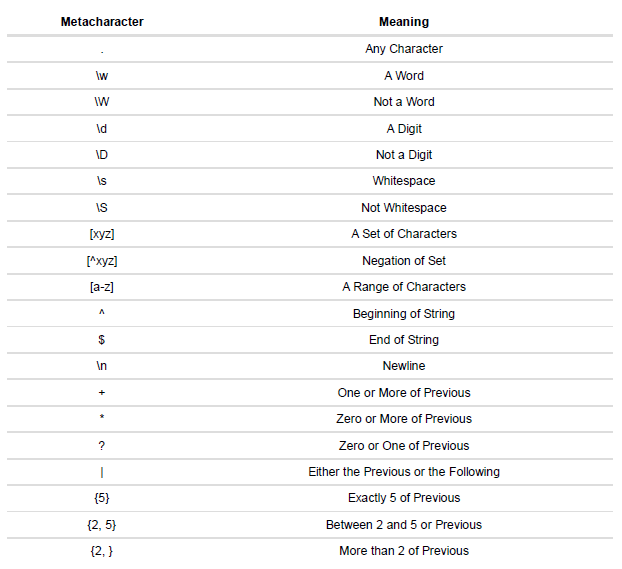

*Fig 2.6: Regular Expression Metacharacters*

**Note** this is only a partial list of *metacharacters*, for a more detailed list see **?regex**.

# Try it!: Manipulating Strings with Regular Expressions

Let’s walk through a few basic examples illustrating **regular expressions** in action.

```r
sntnc

# return index of character string containing "'s" using metacharacters
grep(sntnc, pattern = ".+'s.*")

# extract to the end of the line from wherever "slid" is matched
str_extract(sntnc, pattern = "slid .+$")

# wherever two "e"s or two "l"s occur, replace with "__"
gsub(sntnc, pattern = "[e]{2}|[l]{2}", replace = "__")
```

# Additional Resources

- Today presented a very high-level and basic introduction to using R packages. Things can start to get hairy when you deal with maintaining difference package versions/binaries, isntalling packages from outside CRAN, installing packags from source, etc. If you want to learn more, start with the [R Installation and Administration Manual](https://cran.r-project.org/doc/manuals/r-release/R-admin.html)
- The *lubridate* package is another member of the **tidyverse** family and is useful when working with dates, especially parsing and formatting. It is quick to learn and apply, see the lubridate documentation for a complete list of functions and examples
- Continue working through the **swirl** package and its interactive tutorials

# Case Study: Applying the tidyverse to Mining User Reviews

With the new set of tools learned today, let’s apply them while also introducing basic text mining.

For this section, we will be using the **mining-amazon-reviews.R** file and associated dataset provided along with today’s materials.